# **Úvod**

Projekt - Vizualizácia dát - autor Tadeáš Kaminský.

Cieľom tohto projektu bolo zodpovedať otázku ohľadom významných zemetrasení. Odpovede boli dosiahnuté analyzovaním relevantných vizualizácií, ktoré sú obsahom tohto dokumentu.

[Zdroj dát](https://data.noaa.gov/metaview/page?xml=NOAA/NESDIS/NGDC/MGG/Hazards/iso/xml/G012153.xml&view=getDataView)

# **Načítanie dát**

Načítanie pôvodných dát prebiehalo v inom notebooku, v tomto dokumente som využil dáta, s ktorými sa jednoduchšie pracuje pomocou knižníc v Pythone.

```python
#Inštalácia geopandas
%%capture
!pip install geopandas
```

```python
#Import použitých knižníc
import zipfile
import requests
import io
import numpy as np
import pandas as pd
import geopandas as gpd
import matplotlib.pyplot as plt
import seaborn as sns
import plotly.express as px
```

```python
#Stiahnutie súboru s dátami
url = 'https://github.com/tady88/Earthquakes/raw/main/hazards_geojson.zip'

data = requests.get(url)

with zipfile.ZipFile(io.BytesIO(data.content)) as zip_ref:
    with zip_ref.open('hazards_geojson/earthquakes.geojson', 'r') as file:
        earthquakes = gpd.read_file(file)

print('Významné Zemetrasenia:')
display(earthquakes.head())
display(earthquakes.shape)
```

```
Významné Zemetrasenia:
```

|  | location | magnitude | deaths | tsunami | date | year | geometry |
| --- | --- | --- | --- | --- | --- | --- | --- |
| 0 | JORDAN: BAB-A-DARAA,AL-KARAK | 7.3 | None | 0 | -2150/??/?? | -2150 | POINT (35.50000 31.10000) |
| 1 | TURKMENISTAN: W | 7.1 | Few (~1 to 50 people) | 0 | -2000/??/?? | -2000 | POINT (58.20000 38.00000) |
| 2 | SYRIA: UGARIT | None | Many (~101 to 1000 people) | 1 | -2000/??/?? | -2000 | POINT (35.80000 35.68300) |
| 3 | GREECE: THERA ISLAND (SANTORINI) | None | Many (~101 to 1000 people) | 1 | -1610/??/?? | -1610 | POINT (25.40000 36.40000) |
| 4 | ISRAEL: ARIHA (JERICHO) | None | None | 0 | -1566/??/?? | -1566 | POINT (35.30000 31.50000) |

```
(5884, 7)
```

# **Otázka: Ako súvisí magnitúda zemetrasení s počtom úmrtí?**

Dáta som sa rozhodol vizualizovať pomocou boxplotu, ktorý priblíži, aké hodnoty magnitúdy v porovnaní s úmrtiami pre jednotlivé zemetrasenia existujú.

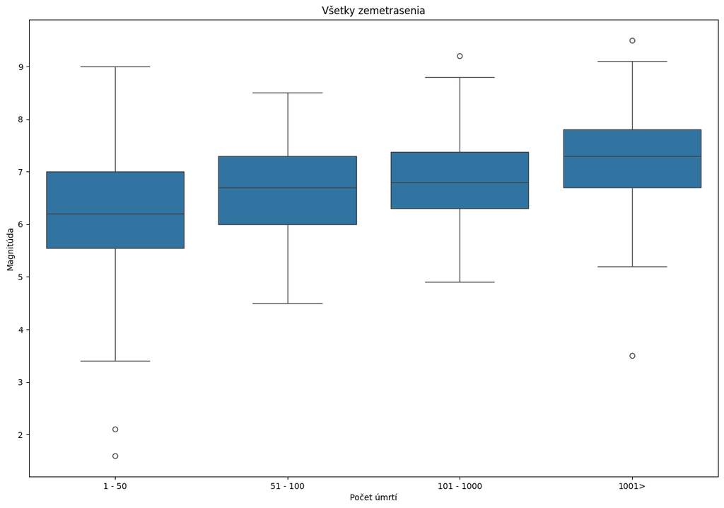

```python
earthquakes1 = earthquakes.copy(deep=True).query("`magnitude`.notnull() and `deaths`.notnull()")
def deaths_parse(value):
    if value is not np.nan:
        index = value.find('(')
        key, value = value[: index].strip(), value[index + 2:]
        ran = ()
        for i in value.split():
             try:
                 ran += int(i),
             except ValueError:
                 pass
        if len(ran) != 2:
            out = (ran[0], '>')
        else:
            out = (ran[0], ran[1])
        return out
    return value


earthquakes1['deaths'] = earthquakes1['deaths'].apply(deaths_parse)
earthquakes1['magnitude'] = earthquakes1['magnitude'].astype(float)
earthquakes1 = earthquakes1.sort_values(by='deaths')
earthquakes1['deaths'] = earthquakes1['deaths'].apply(lambda x: f'{x[0]} - {x[1]}' if x[1] != '>' else f'{x[0]}>')

figure, axes = plt.subplots(figsize=(15, 10))
e_death_scatter = sns.boxplot(data=earthquakes1, x='deaths', y='magnitude')
e_death_scatter.set_ylabel('Magnitúda')
e_death_scatter.set_xlabel('Počet úmrtí')
e_death_scatter.set_title('Všetky zemetrasenia')
pass
```

Na vytvorenom boxplote je vidieť akúsi rastúcu priemernú výšku magnitúdy spolu s nárastom úmrtí. Následne pre ešte lepšiu vizualizáciu dát som si dal vykresliť aj violin plot.

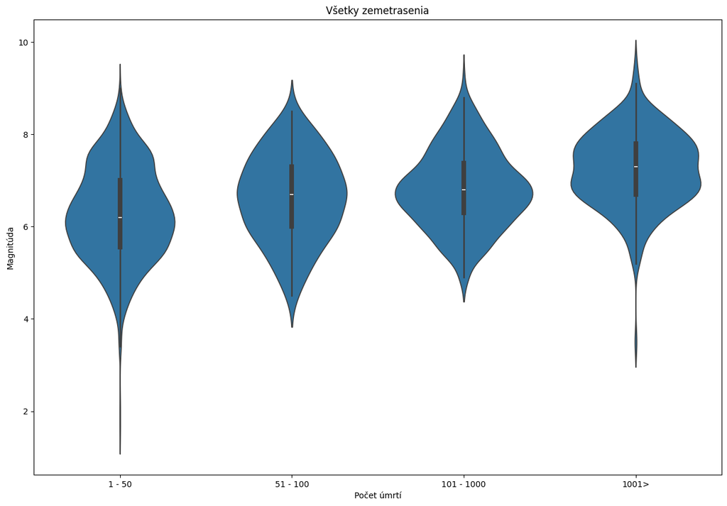

```python
figure, axes = plt.subplots(figsize=(15, 10))
earthquakes1['magnitude'] = earthquakes1['magnitude'].astype(float)


e_death_violin = sns.violinplot(data=earthquakes1, x='deaths', y='magnitude')

low_deaths_max_mag = earthquakes1.query("`deaths` == '1 - 50'")['magnitude'].max()
e_death_violin.set_title('Všetky zemetrasenia')
e_death_violin.set_ylabel('Magnitúda')
e_death_violin.set_xlabel('Počet úmrtí')
pass
```

Môžeme si všimnúť, že každá skupina úmrtí je najviac zastúpená nejakou hodnotou magnitúdy, čo je reprezentované tým, že je samotný graf najširší. V tomto grafe ma ale zaujala časť, v ktorej boli reprezentované zemetrasenia o vysokej magnitude, ale s malým počtom úmrtí. Zaujímalo ma, ako je možné, že niektoré zemetrasenia s veľkou magnitúdou majú málo úmrtí.

### **Mapa nízkej úmrtnosti a nízkej hustoty obyvateľstva po roku 1950**

Môžeme si všimnúť, ako sa magnitúda schodovito vyvíja. Zaujal ma úsek zemetrasení s malým počtom úmrtí, ale vysokou magnitúdou. Domnievam sa, že vysoká magnitúda spôsobila málo úmrtí, pretože poloha epicentra daného zemetrasenia bola v miestach, kde žije málo ľudí.

Môžeme si všimnúť, že veľa z týchto zemetrasení sa nachádza ďalej od pobrežia alebo úplne v oceánoch. Z údajov o hustote obyvateľstva vidíme, že takéto zemetrasenia sa skôr diali v krajinách z nižšou hustotou. Keďže dáta o hustote sú relevantné len za posledných 50 rokov, tak pre väčšiu presnosť porovnáme len zemetrasenia, ktoré sa udiali od roku 1950. Vysoká magnitúda a malý počet úmrtí sú zobrazené na mape v korelácii s hustotou obyvateľstva od roku 1950.

```python
#Dáta o krajinách, z ktorých vytváram hustotu populácie
countries = gpd.read_file(gpd.datasets.get_path('naturalearth_lowres'))
country_areas = countries['geometry'].to_crs({'proj':'cea'}).area  / 1e6
countries['area'] = country_areas
density = (countries['pop_est']
           / countries['area'])
countries['pop_dens'] = density
display(countries.head())
pass
```

|  | pop_est | continent | name | iso_a3 | gdp_md_est | geometry | area | pop_dens |
| --- | --- | --- | --- | --- | --- | --- | --- | --- |
| 0 | 889953.0 | Oceania | Fiji | FJI | 5496 | MULTIPOLYGON (((180.00000 -16.06713, 180.00000... | 1.928760e+04 | 46.141190 |
| 1 | 58005463.0 | Africa | Tanzania | TZA | 63177 | POLYGON ((33.90371 -0.95000, 34.07262 -1.05982... | 9.327793e+05 | 62.185621 |
| 2 | 603253.0 | Africa | W. Sahara | ESH | 907 | POLYGON ((-8.66559 27.65643, -8.66512 27.58948... | 9.666925e+04 | 6.240382 |
| 3 | 37589262.0 | North America | Canada | CAN | 1736425 | MULTIPOLYGON (((-122.84000 49.00000, -122.9742... | 1.003773e+07 | 3.744797 |
| 4 | 328239523.0 | North America | United States of America | USA | 21433226 | MULTIPOLYGON (((-122.84000 49.00000, -120.0000... | 9.509851e+06 | 34.515738 |

```python
high_magnitude_low_deaths = earthquakes1.copy(deep=True).query("`magnitude` > 7.5 and `deaths` == '1 - 50' and year > 1950")

main = px.choropleth(
    countries,
    locations=countries['iso_a3'],
    color='pop_dens',
    color_continuous_scale='Blues',
    range_color=(0, 250),
    projection='mollweide',
    title='Mapa nízkej úmrtnosti a nízkej hustoty obyvateľstva po roku 1950'
)
fig = px.scatter_geo(
    high_magnitude_low_deaths,
    lat=high_magnitude_low_deaths.geometry.y,
    lon=high_magnitude_low_deaths.geometry.x,
    hover_name="location",
    hover_data=['magnitude', 'deaths', 'tsunami', 'date'],
    color_discrete_sequence=['#cb0000'],
    projection="mollweide"
    )
main.add_trace(fig.data[0])
main.update_layout(width=1800, height=1000)
main.show()
```

[interactive chart not shown]

Môžeme vidieť, že tieto zemetrasenia sa diali v krajinách s nízkou hustotou zaľudnenia. Domnievam sa, že ak sa zemetrasenie udeje v niektorej z krajín s nízkou hustotou obyvateľstva (napríklad v lokalitách mimo miest), tak sa následne takéto zemetrasenie neprejaví vysokou úmrtnosťou. V miestach blízko krajín s vysokou zaľudnenosťou pozorujeme epicentrá (až na pár výnimiek) na pobrežiach až ďalej, v moriach a oceánoch.

### **Mapa nízkej úmrtnosti v kombinácii s mestami po roku 1950**

```python
url_cities = 'https://github.com/tady88/Earthquakes/raw/main/worldcities.csv'
cities = pd.read_csv(url_cities)
cities.head()
```

|  | city | city_ascii | lat | lng | country | iso2 | iso3 | admin_name | capital | population | id |
| --- | --- | --- | --- | --- | --- | --- | --- | --- | --- | --- | --- |
| 0 | Tokyo | Tokyo | 35.6897 | 139.6922 | Japan | JP | JPN | Tōkyō | primary | 37732000.0 | 1392685764 |
| 1 | Jakarta | Jakarta | -6.1750 | 106.8275 | Indonesia | ID | IDN | Jakarta | primary | 33756000.0 | 1360771077 |
| 2 | Delhi | Delhi | 28.6100 | 77.2300 | India | IN | IND | Delhi | admin | 32226000.0 | 1356872604 |
| 3 | Guangzhou | Guangzhou | 23.1300 | 113.2600 | China | CN | CHN | Guangdong | admin | 26940000.0 | 1156237133 |
| 4 | Mumbai | Mumbai | 19.0761 | 72.8775 | India | IN | IND | Mahārāshtra | admin | 24973000.0 | 1356226629 |

```python
e_cop = earthquakes.copy(deep=True).query("`deaths`.notnull()")
e_cop['deaths'] = e_cop['deaths'].apply(deaths_parse)
e_cop.magnitude = e_cop.magnitude.astype(float)
e_cop['deaths'] = e_cop['deaths'].apply(lambda x: f'{x[0]} - {x[1]}' if x[1] != '>' else f'{x[0]}>')

main = px.choropleth(
    countries,
    locations=countries['iso_a3'],
    color_discrete_sequence=['#ffffff'],
    projection='mollweide',
    title='Mapa nízkej úmrtnosti v kombinácii s mestami po roku 1950'
)

cities_to_scatter = cities.copy(deep=True).query("`population` > 50000")
towns = px.scatter_geo(
    cities_to_scatter,
    lat=cities_to_scatter.lat,
    lon=cities_to_scatter.lng,
    hover_name='city',
    hover_data=['country', 'population'],
    projection='mollweide'
)

deaths_earthquakes = e_cop.copy(deep=True).query("`magnitude` > 7.5 and `deaths` == '1 - 50' and year > 1950")
deaths = px.scatter_geo(
    deaths_earthquakes,
    lat=deaths_earthquakes.geometry.y,
    lon=deaths_earthquakes.geometry.x,
    hover_name='date',
    hover_data=['deaths'],
    color_discrete_sequence=['#cb0000'],
    size='magnitude',
    projection='mollweide'
)

main.add_trace(towns.data[0])
main.add_trace(deaths.data[0])
main.update_layout(width=1800, height=1000, geo = dict(showlakes=False))
main.show()
```

[interactive chart not shown]

Môžeme si všimnúť, že takmer všetky zemetrasenia s magnitúdou vyššou ako 7.5 sa udiali ďalej od veľkých miest, resp. hustejšie obývaných častí sveta. Ako dobrý príklad slúži Japonsko, konkrétne jeho severná časť, ktorá je redšie obývaná ako juh. 6 zemetrasení mimo Japonska, resp. ďalej od obyvateľov spôsobilo nízky počet úmrtí vzhľadom na vysokú magnitúdu.

### **Mapa vysokej úmrtnosti a vysokej hustoty obyvateľstva po roku 1950**

```python
e_high_deaths = earthquakes1.query("`deaths` == '1001>' and `year` > 1950")

main = px.choropleth(
    countries,
    locations=countries['iso_a3'],
    color='pop_dens',
    color_continuous_scale='Blues',
    range_color=(0, 250),
    projection='mollweide',
    title='Mapa vysokej úmrtnosti a vysokej hustoty obyvateľstva po roku 1950'
)
fig = px.scatter_geo(
    e_high_deaths,
    lat=e_high_deaths.geometry.y,
    lon=e_high_deaths.geometry.x,
    hover_name="location",
    hover_data=['magnitude', 'deaths', 'tsunami', 'date'],
    color_discrete_sequence=['#cb0000'],
    projection="mollweide"
    )
main.add_trace(fig.data[0])
main.update_layout(width=1800, height=1000)
main.show()
```

[interactive chart not shown]

Na mape môžeme vidieť znázornenú hustotu jednotlivých štátov podľa sýtosti modrej farby a zemetrasenia s vysokou úmrtnosťou zobrazené červenými bodmi.

Môžeme pozorovať, že tieto zemetrasenia mali epicentrá prevažne vo vnútrozemí. To môže znamenať, že sa epicentrá týchto zemetrasení s veľkou úmrtnosťou orientovali v okolí veľkých miest alebo v samotých mestách krajín s veľkou hustotou zaľudnenia. Na tomto grafe si môžeme všimnúť, že skoro žiadne so zemetrasení sa nenachádza v mori/oceáne, čo potvrdzuje myšlienku z predošlého grafu, že zemetrasenia v oceánoch nemusia mať až taký veľký vplyv na súš. Pár epicentier existuje rovnakých ako pri zemetraseniach s vysokou magnitúdou, ale malou úmrtnosťou. Pri týchto sa môžeme domnievať, že sa jednalo o iné vplyvy, ktoré tento jav spôsobili.

### **Mapa vysokej úmrtnosti v kombinácii s mestami po roku 1950**

Na mape porovnám ešte zemetrasenia s vysokou úmrtnosťou s mestami s počtom obyvateľov nad 50 000.

```python
main = px.choropleth(
    countries,
    locations=countries['iso_a3'],
    color_discrete_sequence=['#ffffff'],
    projection='mollweide',
    title='Mapa vysokej úmrtnosti v kombinácii s mestami po roku 1950'
)

cities_to_scatter = cities.copy(deep=True).query("`population` > 50000")
towns = px.scatter_geo(
    cities_to_scatter,
    lat=cities_to_scatter.lat,
    lon=cities_to_scatter.lng,
    hover_name='city',
    hover_data=['country', 'population'],
    projection='mollweide'
)

deaths_earthquakes = e_cop.copy(deep=True).query("`deaths` == '1001>' and year > 1950")
deaths = px.scatter_geo(
    deaths_earthquakes,
    lat=deaths_earthquakes.geometry.y,
    lon=deaths_earthquakes.geometry.x,
    hover_name='date',
    hover_data=['deaths'],
    color_discrete_sequence=['#cb0000'],
    size='magnitude',
    projection='mollweide'
)

main.add_trace(towns.data[0])
main.add_trace(deaths.data[0])
main.update_layout(width=1800, height=1000, geo = dict(showlakes=False))
main.show()
```

[interactive chart not shown]

Na mape vidíme znázornenie miest s počtom obyvateľov nad 50 000 (modré body) a zemetrasenia s veľkým počtom úmrtí.

Môžeme si všimnúť, že v územiach s vyššou koncentráciou miest je viacero zemetrasení, ktoré spôsobili viac ako 1001 úmrtí. (Viac informácií mi tabuľka neposkytla.)

# **Záver**

Závislosť úmrtnosti od magnitúdy nezáleží až tak od veľkosti magnitúdy ako skôr od lokality daného epicentra. Po analýze múžem tvrdiť, že zemetrasenia s epicentrami mimo pevniny neprispievajú až tak k úmrtnosti zapríčinenou zemetrasením bez ohľadu na ich veľkosť, ako naopak zemetrasenia s nižšou magnitúdou, ale na pevnine. Dalo by sa teda povedať, že úmrtnosť záleží od lokality zemetrasenia v závislosti od toho, aká veľká je magnitúda.